# ScITree

```r
## Necessary packages
library(ScTree)

library(ggplot2)
library(ape)
library(dplyr)
base_dir <- "~/Documents/Research/Phylodynamics/ScTree/vignettes/"

knitr::opts_knit$set(root.dir = base_dir)
```

To use this vignette, first set the starting directory on your computer. This vignette will create a directory for the simulation and a directory for the inference.

```r
## Run setup
## Simulation seed
random_seed <- 108

set.seed(seed=random_seed)
```

# ScITree

This vignette will walk you through an example simulation and analysis using the package. https://www.biorxiv.org/content/10.1101/2024.11.20.624621v1

# Simulation

A simulation takes, as its input: - Geographic location data of individuals/premises - Key epidemic parameters $\alpha, \beta, \kappa, a, b, c, d, \mu_1, \mu_2$, and $p$, as described in the manuscript and in the format for the sim.param.key object. - Auxiliary parameters for population size, random seed, length of genetic sequences, outbreak length, and other settings, as found in the sim.param.aux example.

The simulation generates, as its output: - Epidemic data with time of exposure, time of infectiousness, and time of recovery/removal - Transmission tree of who-infected-whom in the outbreak - Genetic sequence data associated with transmission and sampling events

Now, we set the parameters for the simulation. These are epidemic parameters, plus the maximum x and y coordinates which we will use to generate the epidemic data.

```r
n_pop <- 150 # Number of individuals in the population
nbase <- 8000 # Number of pathogen nucleotide bases
tmax <- 100 # Maximum time of outbreak

alphaval <- 0.0001 # Background infection rate
betaval <- 8 # Infectious pressure
kappaval <- 0.02 # Exponential kernel decay rate
aval <- 10 # Exposed sojourn shape (gamma distribution)
bval <- 0.5 # Exposed sojourn scale (gamma distribution)
cval <- 2 # Infectious sojourn shape (Weibull distribution)
dval <- 2 # Infectious sojourn scale (Weibull distribution)
mu1val <- 0.002 # Kimura substitution model transition rate
mu2val <- 0.0005 # Kimura substitution model transversion rate
pval <- 0.0001 # Mutation probability from "grand master" background sequence

maxx <- 2000 # Maximum x coordinate
maxy <- 2000 # Maximum y coordinate
```

We now generate our input epidemiological data, with columns for index/ID, X and Y coordinates, and our initial values for exposure time, infectious time, and removal time. If the time is meant to be unknown, fill in with 9,000,000.

```r
sim.epi.data <- data.frame(k=0:(n_pop-1), ## Index
                           coor_x=runif(n_pop,0,maxx), ## X coordinates
                           coor_y=runif(n_pop,0,maxy), ## Y coordinates
                           t_e=c(0,rep(9e+06,n_pop-1)), ## Exposure time
                           t_i=rep(9e+06,n_pop), ## Infectious time
                           t_r=rep(9e+06,n_pop), ## Removal time
                           ftype0=sample(c(0,1),n_pop,replace=T), ## Unused
                           herdn=sample(min(sim.epi.input$herdn):max(sim.epi.input$herdn),
                                        n_pop,
                                        replace=T), ## Unused
                           status=c(2,rep(1,n_pop-1))) ## Unused

sim.epi.data$ftype1=ifelse(sim.epi.data$ftype0==1,
              0,
              sample(c(0,1),n_pop,replace=T)) ## Unused
sim.epi.data$ftype2=ifelse(sim.epi.data$ftype0==0 & sim.epi.data$ftype1==0,
              1,
              0) ## Unused

data(sim.epi.input)
sim.epi.data <- sim.epi.data[,names(sim.epi.input)]
```

The following parameters govern the number of MCMC iterations, plus the frequency of output.

```r
niter = 20 # Number of iterations
nfrequ = round(niter/2) # Number of individuals to update at each iteration
noutputsource = max(round(niter/10000),1) # Frequency of source output
noutputgm = max(round(niter/1000),1) # Frequency of grand master sequence output (not used)
ncout = max(round(niter/1000),1) # Frequency of console output

nburn = round(niter/10) # Number of burnin iterations
```

The following sets of parameters define the key scalar parameters and important auxiliary parameters which govern the simulation.

```r
para.key <- data.frame('alpha' = alphaval,
                       'beta' = betaval,
                       'mu_1' = mu1val,
                       'mu_2' = mu2val,
                       'a' = aval,
                       'b' = bval,
                       'c' = cval,
                       'd' = dval,
                       'k_1' = kappaval,
                       'p_ber' = pval,
                       'phi_inf1' = 3,
                       'phi_inf2' = 1.5,
                       'rho_susc1' = 0.4,
                       'rho_susc2' = 2,
                       'nu_inf' = 0.2,
                       'tau_susc'= 0.1,
                       'beta_m'= 1.0)

pars.aux <- data.frame('n' = nrow(sim.epi.data),
                       'seed' = random_seed,
                       'n_base' = nbase,
                       'n_seq' = 5,
                       't_max' = tmax,
                       'unassigned_time' =  9e+6,
                       'sample_range' = 10,
                       'partial_seq_out' = 0,
                       'n_base_part' = nbase,
                       'n_index' = 1,
                       'coord_type' = 'cartesian',
                       'kernel_type' = 'exponential',
                       'latent_type' = 'gamma',
                       'opt_k80' = 0,
                       'opt_betaij' = 0,
                       'opt_mov' = 0,
                       'n_mov' = 60,
                       stringsAsFactors = F)

if(!dir.exists("./Sim_Test")){
  dir.create("./Sim_Test")
}

knitr::opts_knit$set(root.dir = "./Sim_Test")
```

We now simulate the outbreak.

```r
sim.out <- sim(epi.inputs = sim.epi.data,
               moves.inputs = sim.moves.input,
               parsKey = para.key,
               parsAux = pars.aux,
               inputPath = "./inputs",
               outputPath = "./outputs")
```

```
#> Input path: ./inputs/
#> Output path: ./outputs/
#>
#> Outbreak simulated successfully.
#>
```

We have now simulated our outbreak, and we make a quick summary.

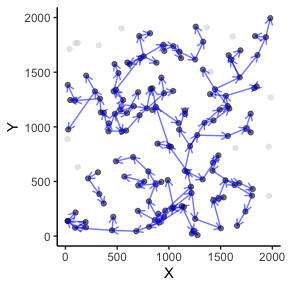

```r
arrow_outbreak_plot <- function(epi.data,true.source.c,t.max=100){
  epi.data.df <- as.data.frame(epi.data)
  true_source_r <- true.source.c + 1
  true_source_r[true_source_r > nrow(epi.data) | true_source_r < 0] <- NA
  epi.data.df$arrow_start_x <- epi.data.df$coor_x[true_source_r]
  epi.data.df$arrow_start_y <- epi.data.df$coor_y[true_source_r]

  is.infected <- ifelse(epi.data.df$t_e <= t.max,"yes","no")
  return(epi.data.df %>% ggplot(aes(x=coor_x,y=coor_y,alpha=0.83)) +
           geom_point(mapping=aes(colour=is.infected)) +
           scale_color_manual(values=c("no"="grey85","yes"="white")) +
           geom_point(data=subset(epi.data.df,is.infected=="yes")) +
           theme_classic() +
           geom_point(data=subset(epi.data.df,true_source_r==10000),shape=3) +
           geom_segment(aes(x=arrow_start_x,y=arrow_start_y,xend=coor_x,yend=coor_y),arrow=arrow(length=unit(0.2,'cm')),color="blue") +
           guides(colour="none",is.infected="none",alpha="none") +
           xlab("X") + ylab("Y"))
}

outbreak_plot <- arrow_outbreak_plot(sim.out$epi.sim,sim.out$infected_source,tmax)
print(outbreak_plot)
```

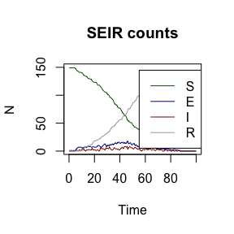

```r
countSEIRt <- function(tval,te,ti,tr){
  ns <- sum(te > tval & ti > tval & tr > tval)
  ne <- sum(te <= tval & ti > tval & tr > tval)
  ni <- sum(te <= tval & ti <= tval & tr > tval)
  nr <- sum(te <= tval & ti <= tval & tr <= tval)

  return(c(ns,ne,ni,nr))
}

countSEIR <- function(te,ti,tr,tmax.outbreak=100){
  tpoints <- seq(from=0,to=tmax.outbreak,length.out=200)
  ns <- rep(0,length(tpoints))
  ne <- rep(0,length(tpoints))
  ni <- rep(0,length(tpoints))
  nr <- rep(0,length(tpoints))

  for(i in 1:length(tpoints)){
    countcat <- countSEIRt(tpoints[i],te,ti,tr)

    ns[i] <- countcat[1]
    ne[i] <- countcat[2]
    ni[i] <- countcat[3]
    nr[i] <- countcat[4]
  }

  npop <- length(te)

  return(data.frame(time=tpoints,NS=ns,NE=ne,NI=ni,NR=nr))
}

sim_data <- read.csv("./outputs/epi_sim.csv")

seir_count <- countSEIR(sim_data$t_e,sim_data$t_i,sim_data$t_r,tmax)

plot(seir_count$time,seir_count$NS,main="SEIR counts",xlab="Time",ylab="N",col="darkgreen",type="l",xlim=c(0,tmax),ylim=c(0,length(sim_data$t_e)))
lines(seir_count$time,seir_count$NE,col="darkblue")
lines(seir_count$time,seir_count$NI,col="darkred")
lines(seir_count$time,seir_count$NR,col="darkgrey")
legend("right",col=c("darkgreen","darkblue","darkred","darkgrey"),lty=1,legend=c("S","E","I","R"))
```

We now prepare to set up our inference. We will prepare the genetic data input to the inference from the simulated genetic sequences.

A ScITree inference takes a .FASTA file of sampled genetic sequences as input, with the names of the sequences denoting the individual’s index number and the time of sampling.

```r
dir.create("../Infer_Test")

fn <- paste0(sim.out$outputPath, "subject_0_nt.txt")
seqs1 <- as.matrix(read.csv(fn, header=F))

#convert the sequences to their nucleotide base letters
seqs1[seqs1==1]<-"a"
seqs1[seqs1==2]<-"g"
seqs1[seqs1==3]<-"t"
seqs1[seqs1==4]<-"c"

#name the rows, which become the tip labels in the fasta file.
#for this we will import the timings associated with each sequence
fn <- paste0(sim.out$outputPath, "subject_0_t_nt.txt")
seqs1_t <- as.numeric(unlist(read.table(fn)))

rownames(seqs1) <- paste0("k0_", round(seqs1_t,3))

write.dna(seqs1, file='seqs1.fasta', format = 'fasta', nbcol = -1)

epi.data <- as.data.frame(sim.out$epi.sim)

#make sure indexing is correct
epi.data$k<-1:nrow(epi.data)-1

#produce the required initial values for the temporal fields.
#assume that exposure has occurred 24 hours before the onset of infectiousness:
epi.data$t_e <- epi.data$t_i - 1

epi.data$t_e[epi.data$t_e > 10000] <- pars.aux$unassigned_time
epi.data$t_r <- round(epi.data$t_r, 0)

# UNUSED
#wrangle the farm type variables into the required format
epi.data$ftype <- NA
epi.data$ftype[epi.data$ftype0 == 1] <- 0
epi.data$ftype[epi.data$ftype1 == 1] <- 1
epi.data$ftype[epi.data$ftype2 == 1] <- 2

epi.data<-epi.data[,c('k','coor_x','coor_y','t_e','t_i','t_r','ftype','herdn')]
head(epi.data)
```

```
#>   k     coor_x     coor_y       t_e       t_i t_r ftype herdn
#> 1 0  910.11608  125.40049  3.470867  4.470867   9     0  1206
#> 2 1  807.92211   85.21791  9.832893 10.832893  12     1  2877
#> 3 2  702.59534 1316.74777 41.977871 42.977871  46     2  2684
#> 4 3 1328.59570 1524.52391 68.530534 69.530534  70     1   328
#> 5 4  926.94295 1450.21798 50.460837 51.460837  53     0  4019
#> 6 5   46.27288 1245.73180 50.165613 51.165613  53     0   803
```

We initialize the source of infection based on “available” infectious individuals at the initial time of exposure (simply assumed to be 1 day before the infectious time).

```r
epi.data$initial_source<-NA

for (i in 1:nrow(epi.data)){

  epi.data$k[i]

  #identify the pool of possible sources with earlier initial exposure times
  pool_source<- epi.data$k [which(epi.data$t_e<epi.data$t_e[i] & epi.data$t_r>epi.data$t_e[i])]

  #randomly assign an infection source is there are any in the pool
  if (length(pool_source)>1) epi.data$initial_source[i] <- sample(pool_source,1)
  if (length(pool_source)==1) epi.data$initial_source[i] <- pool_source[1]

  #otherwise assign 9999 as the initial source, to indicate that it is either external to the dataset or unknown
  if (length(pool_source)<1) epi.data$initial_source[i] <- 9999

}
epi.data$initial_source
```

```
#>   [1] 9999   97   11  141  129  129  112  136   40   26  121   69  130   95  103
#>  [16]   52   71    1  111  146   63  127 9999   24    8  139   29   57   45   98
#>  [31] 9999    4   23    5   62   21   44   38  112   51  139 9999   68  134   38
#>  [46]   85 9999 9999   40 9999   64  109  108 9999   77  113  148  111  126  100
#>  [61]   68   13   66   51   35  140    7  128   89  136  108   68  104   39   26
#>  [76]   37  102   14  141 9999   89  144    7   14   54    7  149   83   34   34
#>  [91]   61 9999   59  146 9999  120  144  148   43 9999   57   95   17   93   87
#> [106]   54 9999   34   24   14   22  143  102   86  108   13   77  107   44   69
#> [121]  128  119   74   18   54  148    5   85   92   42   57 9999  148 9999  140
#> [136]    2   32 9999 9999   54  107   92  112  144   26   32   44   13    0  124
```

```r
## UNUSED
#use the movement data from previously
moves.inputs<-sim.out$moves.inputs
head(moves.inputs)
```

```
#>   from_k to_k t_m
#> 1      0    1   9
#> 2      0    2   9
#> 3      0    3   9
#> 4      0    4   9
#> 5      0    5   9
#> 6      0    6   9
```

We now set up the parameters for the inference. The inference takes in several lists of settings:

1. Initial values for the scalar parameters, in the format of infer.param.key
2. Prior distribution parameters for scalar parameters, in the format of infer.param.priors
3. Standard deviations (scaling factors) for the normal proposal distributions for scalar parameters, in the format of infer.param.sf
4. Auxiliary parameters which control inference settings, in the format of infer.param.aux

```r
pars.aux <- data.frame('n' = nrow(epi.data),
                       'kernel_type' = 'exponential',
                       'coord_type' = 'cartesian',
                       't_max' = tmax,
                       'unassigned_time' =  9e+6,
                       'processes' = 1,
                       'n_seq' = 5,
                       'n_base' = nbase,
                       'n_iterations' = 1e5,
                       'n_frequ' = 10,
                       'n_output_source' = 1000,
                       'n_output_gm' = 2000,
                       'n_cout' = 1000,
                       'opt_latgamma' = 0,
                       'opt_k80' = 0,
                       'opt_betaij' = 0,
                       'opt_ti_update' = 0,
                       'opt_mov' = 0,
                       stringsAsFactors = F)

#once `t_max` is set, right censor all recovery times
epi.data$t_r[epi.data$t_r>pars.aux$t_max]<-pars.aux$t_max

para.key.inits <- data.frame('alpha' = para.key$alpha,
                             'beta' = para.key$beta/2,
                             'lat_mu' = para.key$a,
                             'lat_var' = para.key$b,
                             'c' = para.key$c*2,
                             'd' = para.key$d*2,
                             'k_1' = para.key$k_1*2,
                             'mu_1' = para.key$mu_1*0.5,
                             'mu_2' = para.key$mu_2*0.5,
                             'p_ber' = para.key$p_ber*2,
                             'phi_inf1' = 3,
                             'phi_inf2' = 1.5,
                             'rho_susc1' = 0.4,
                             'rho_susc2' = 2,
                             'nu_inf' = 0.2,
                             'tau_susc'= 0.1,
                             'beta_m'= 1)

para.priors <- data.frame('t_range' = 20,
                          't_back' = (para.key$a*para.key$b^2)*2,
                          't_bound_hi' = 40,
                          'rate_exp_prior' = 0.001,
                          'ind_n_base_part' = 0,
                          'n_base_part' = nbase,
                          'alpha_hi' = 0.1,
                          'beta_hi' = 30,
                          'mu_lat_hi' = 50,
                          'var_lat_lo' = 0.1,
                          'var_lat_hi' = 50,
                          'c_hi' = 100,
                          'd_hi' = 100,
                          'k_1_lo' = 0,
                          'k_1_hi' = 10,
                          'mu_1_hi' = 44,
                          'mu_2_hi' = 0.1,
                          'p_ber_hi' = 1.0,
                          'phi_inf1_hi' = 500,
                          'phi_inf2_hi' = 500,
                          'rho_susc1_hi' = 500,
                          'rho_susc2_hi' = 500,
                          'nu_inf_lo' = 0,
                          'nu_inf_hi' = 1,
                          'tau_susc_lo' = 0,
                          'tau_susc_hi' = 1,
                          'beta_m_hi' = 5,
                          'trace_window' = 20)

para.sf <- data.frame('alpha_sf' = para.key$alpha*1.5,
                      'beta_sf' = para.key$beta*0.55,
                      'mu_lat_sf'   = 2,
                      'var_lat_sf' = 1,
                      'c_sf' = 1.25,
                      'd_sf' = 0.75,
                      'k_1_sf' = 0.01,
                      'mu_1_sf' = 0.2,
                      'mu_2_sf' = 2.5e-6,
                      'p_ber_sf' = 0.02,
                      'phi_inf1_sf' = 1.75,
                      'phi_inf2_sf' = 1.5,
                      'rho_susc1_sf' = 1,
                      'rho_susc2_sf' = 1.25,
                      'nu_inf_sf' = 0.25,
                      'tau_susc_sf' = 0.25,
                      'beta_m_sf' = 1)
```

We now create the .FASTA file with the sampled sequences.

```r
t_sample <- sim.out$t_sample

no.genome <- which(t_sample == pars.aux$unassigned_time)
genome.sampled <- which(t_sample != pars.aux$unassigned_time)

#identify and store the data from sequences at the time of sampling
#the next step takes approximately 30 seconds to run
seq_mat<-matrix(nrow=nrow(epi.data), ncol=pars.aux$n_base)

for(i in 1:nrow(epi.data)){
  k <- i-1
  if(i %in% no.genome){
    #these are not used, given t.sample for these = the unassigned time
    #n denotes any base (in the IUPAC system)
    seq_mat[i,]<-rep("n", pars.aux$n_base)
  }else{
    #identify the closest corresponding sample to the time of
    #sampling for each sampled individual
    fn<-paste0(sim.out$outputPath,"subject_",k,"_t_nt.txt")
    ts<-as.numeric(unlist(read.csv(fn, header=F)))
    tsamp <- which.min(abs(ts - t_sample[i]))
    #read in the corresponding nucleotide sequence
    fn<-paste0(sim.out$outputPath,"subject_",k,"_nt.txt")
    nts<-read.csv(fn, header = F, stringsAsFactors = F)
    #store the closest corresponding sample for this individual
    seq_mat[i,]<-as.numeric(nts[tsamp,])
  }
  if((i%%2) == 0) {cat(".",sep=""); flush.console()}  #
}
```

```
#> ...........................................................................
```

```r
#convert the sequence data to their nucleotide base letters
seq_mat[seq_mat==1]<-"a"
seq_mat[seq_mat==2]<-"g"
seq_mat[seq_mat==3]<-"t"
seq_mat[seq_mat==4]<-"c"

#write row.names to the sequence matrix object, including the 'k'
#and time of sampling. These will be used as tip labels
row.names(seq_mat)<- paste0(epi.data$k, "_", round(sim.out$t_sample,0))

if(!dir.exists("../Infer_Test/gen_inputs")) {
  dir.create("../Infer_Test/gen_inputs")
}

write.dna(seq_mat, file='../Infer_Test/gen_inputs/seqs.fasta', format = 'fasta', nbcol = -1)
```

```r
knitr::opts_knit$set(root.dir = base_dir)
knitr::opts_knit$set(root.dir = "./Infer_Test/")
```

```r
pars.aux$n_iterations = niter
pars.aux$n_frequ = nfrequ
pars.aux$n_output_source = noutputsource
pars.aux$n_output_gm = noutputgm
pars.aux$n_cout = ncout

sink(file = "inference_output.txt")
infer.out<-infer(covariates = epi.data,
                 moves.inputs = moves.inputs,
                 parsAux = pars.aux,
                 keyInits = para.key.inits,
                 priors = para.priors,
                 scalingFactors = para.sf,
                 seed = random_seed + 1,
                 accTable = sim.out$infected_source,
                 t.sample = sim.out$t_sample,
                 inputPath = "./inputs",
                 outputPath = "./outputs",
                 dnaPath = "./gen_inputs",
                 dnaReference = F)
sink(file=NULL)
```

We summarize the inference with several included R scripts.

The parameter_capture.R file examines the scalar parameter MCMC, the posterior_tree_capture.R file examines the identification of the correct source, and the bubble_plot.R file maps the percent correct posterior identification of infection sources.

```r
source("../../test/parameter_capture.R")
```

```
#> [1] "Accept P Lambda: 0.68421052631579"
```

```r
source("../../test/posterior_tree_capture.R")
```

```
#> [1] "which incorrect (c index)"
#> [1] "2, 11, 28, 32, 37, 45, 57, 66, 71, 91, 103, 104, 111, 113, 121, 127, 135, 145, 146, 149"
#> [1] "true source"
#>  [1] 108  23  84  25 125  52   9   8  66  61  37  63  60  73 119  86   7  40   6
#> [20] 139
#> [1] "estimated source"
#>  [1]  24  40   2 103  56 149  18 114   8  18 125  19  10  19  11   8  40  84  56
#> [20]  39
#> [1] "Percent of posterior, first most likely, incorrect"
#>  [1] 0.4000000 0.9666667 1.0000000 0.5666667 0.5000000 0.6000000 0.9666667
#>  [8] 0.5333333 1.0000000 0.8666667 0.5333333 1.0000000 0.7000000 1.0000000
#> [15] 0.6000000 0.7333333 0.8666667 0.8333333 1.0000000 0.8000000
#> [1] "Percent of posterior, second most likely"
#>  [1] 0.33333333 0.03333333         NA 0.20000000 0.33333333 0.33333333
#>  [7] 0.03333333 0.33333333         NA 0.13333333 0.30000000         NA
```

[output cut: 196 more lines]

[figure not shown]

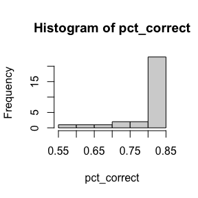

```r
source("../../test/bubble_plot.R")
```